# Data607FinalProjectSadiaBanuPart2

Banu Boopalan

12/11/2019

#### PROJECT TEAM: SADIA AND BANU DATA 607 FINAL PROJECT (PART2 DOCUMENT)

### ANALYSIS:

Our second part of the analyis was to understand how to scrape Wikipedia for metoo webpage and then store that in Neo4j and retrieve data. The goal was to see if we can explain graph database and understand and expand on modeling topics through neo4j in the future. For this we will need to install neo4j and use RNeo4j library from github https://github.com/nicolewhite/RNeo4j#nodes to query the data model in Cypher.

```r
url <- "https://en.wikipedia.org/wiki/Me_Too_movement"

  tag_headline <- url %>%
    read_html() %>%
    html_nodes(xpath = "//h3") %>%
    html_text()

  tag_text <- url %>%
    read_html() %>%
    html_nodes(xpath = "//p | //h3") %>%
    html_text()

  tag_text[1:1]
```

```
## [1] "\n"
```

```r
str(tag_headline)
```

```
##  chr [1:71] "Awareness and empathy" "Policies and laws" ...
```

```r
str(tag_text)
```

```
##  chr [1:285] "\n" "\n" ...
```

```r
df1 <- as.data.frame(tag_headline)

df2 <- as.data.frame(tag_text)
str(df2)
```

```
## 'data.frame':    285 obs. of  1 variable:
##  $ tag_text: Factor w/ 284 levels " Japan","\n",..: 2 2 242 210 80 279 25 247 26 53 ...
```

```r
colnames(df1)[1] <- "matchcol"
colnames(df2)[1] <- "matchcol"

str(df1)
```

```
## 'data.frame':    71 obs. of  1 variable:
##  $ matchcol: Factor w/ 71 levels " Japan","\n\t\t\t\tVariants\n\t\t\t",..: 11 53 36 30 58 59 4 5 6 7 ...
```

```r
str(df2)
```

```
## 'data.frame':    285 obs. of  1 variable:
##  $ matchcol: Factor w/ 284 levels " Japan","\n",..: 2 2 242 210 80 279 25 247 26 53 ...
```

```r
df1 %>%
  mutate_if(is.factor, as.character) %>%
  glimpse()
```

```
## Observations: 71
## Variables: 1
## $ matchcol <chr> "Awareness and empathy", "Policies and laws", "Media ...
```

```r
df2 %>%
  mutate_if(is.factor, as.character) %>%
  glimpse()
```

```
## Observations: 285
## Variables: 1
## $ matchcol <chr> "\n", "\n", "The Me Too movement (or #MeToo movement)...
```

```r
df3 <- merge(df1, df2, by = "matchcol", all.y = TRUE)

df4 <- cbind(df2,length(df2$matchcol))

list <- nchar(as.character(df4$matchcol))

final <- cbind(df4,list)

 tagheadline <- cbind(df1,nchar(as.character(df1$matchcol)))

final1 <- cbind(final, ifelse(nchar(as.character(df4$matchcol)) <=48, "headline", "Paragraph"))

str(final1)
```

```
## 'data.frame':    285 obs. of  4 variables:
##  $ matchcol                                                                : Factor w/ 284 levels " Japan","\n",..: 2 2 242 210 80 279 25 247 26 53 ...
##  $ length(df2$matchcol)                                                    : int  285 285 285 285 285 285 285 285 285 285 ...
##  $ list                                                                    : int  1 1 325 410 666 165 326 361 669 21 ...
##  $ ifelse(nchar(as.character(df4$matchcol)) <= 48, "headline", "Paragraph"): Factor w/ 2 levels "headline","Paragraph": 1 1 2 2 2 2 2 2 2 1 ...
```

```r
#final data
newdata <- final1[which(final1$list > 1),]

bigrams <- newdata[110:231,] %>%
  unnest_tokens(token1, matchcol, token = "ngrams", n = 2) %>%
  separate(token1, c("word1", "word2"), sep = " ") %>%
  filter(!word1 %in% stop_words$word,
         !word2 %in% stop_words$word) %>%
  count(word1, word2, sort = TRUE)

#count words co-occuring within sections

colnames(newdata)[4] <- "flag"

tokennewdata <- newdata[110:231,] %>%
  unnest_tokens(token1, matchcol, token = "ngrams", n = 1) %>% filter(!token1 %in% stop_words$word) %>% group_by(token1) %>% filter(n()>=20)%>% pairwise_cor(token1,flag,sort=TRUE)

tokennewdata[100,]
```

```
## # A tibble: 1 x 3
##   item1    item2      correlation
##   <chr>    <chr>            <dbl>
## 1 movement harassment       1.000
```

## Plot bigrams of scrapped webpage on metoo main wiki page

```r
# filter for only relatively common combinations
bigram_graph <- bigrams%>%
  filter(n > 1) %>%
  graph_from_data_frame()

bigram_graph
```

```
## IGRAPH b133acc DN-- 137 93 --
## + attr: name (v/c), n (e/n)
## + edges from b133acc (vertex names):
##  [1] sexual     ->harassment  sexual     ->assault
##  [3] metoo      ->movement    social     ->media
##  [5] sexual     ->misconduct  sexual     ->abuse
##  [7] sexual     ->violence    january    ->2018
##  [9] sexually   ->assaulted   law        ->enforcement
## [11] prime      ->minister    sexual     ->advances
## [13] women      ->including   experienced->sexual
## [15] harvey     ->weinstein   human      ->rights
## + ... omitted several edges
```

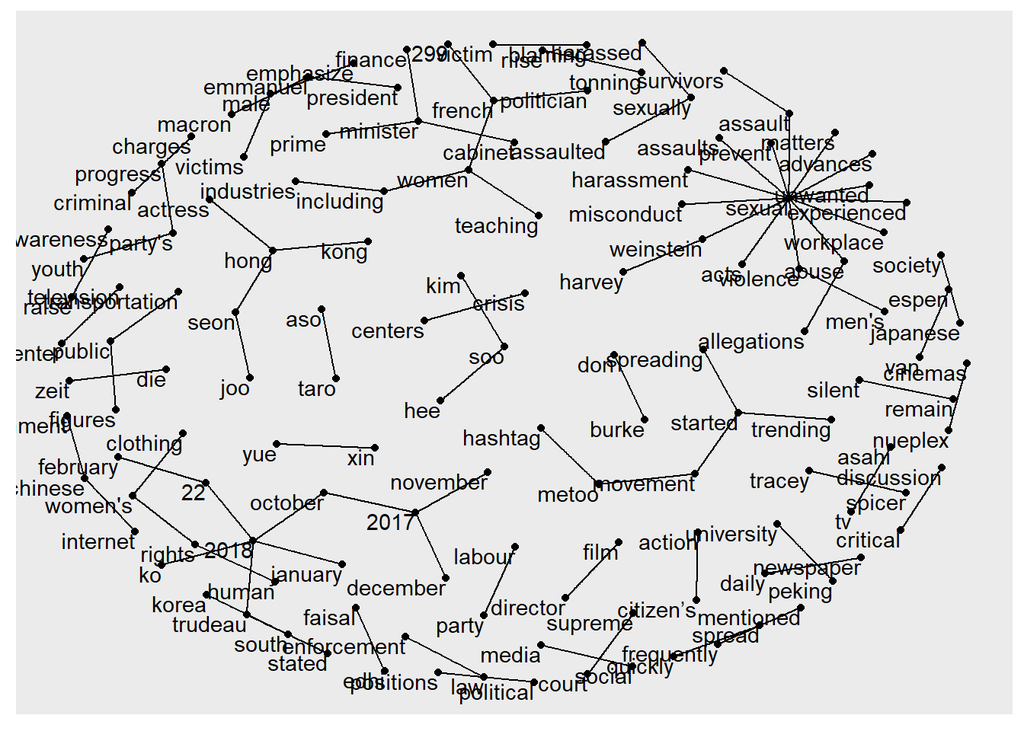

```r
set.seed(2017)

ggraph(bigram_graph, layout = "kk") +
  geom_edge_link() +
  geom_node_point() +
  geom_node_text(aes(label = name), vjust = 1, hjust = 1)
```

```r
#Neo4j section
```

## Loop through to figure out how to assign headline/paragraph for the sections that are together.

For instance, a headline can have multiple paragraphs so loop and assign the flag correctly as these are needed to build a Neo4j datamodel

```r
as.numeric(rownames(newdata[2,]))
```

```
## [1] 4
```

```r
str(newdata)
```

```
## 'data.frame':    283 obs. of  4 variables:
##  $ matchcol            : Factor w/ 284 levels " Japan","\n",..: 242 210 80 279 25 247 26 53 39 58 ...
##  $ length(df2$matchcol): int  285 285 285 285 285 285 285 285 285 285 ...
##  $ list                : int  325 410 666 165 326 361 669 21 501 553 ...
##  $ flag                : Factor w/ 2 levels "headline","Paragraph": 2 2 2 2 2 2 2 1 2 2 ...
```

```r
newdata1 <- newdata %>% mutate_if(is.factor, as.character)
str(newdata1)
```

```
## 'data.frame':    283 obs. of  4 variables:
##  $ matchcol            : chr  "The Me Too movement (or #MeToo movement), with a large variety of local and international related names, is a m"| __truncated__ "Similar to other social justice and empowerment movements based upon breaking silence, the purpose of \"Me Too\"| __truncated__ "Followin…
##  $ length(df2$matchcol): int  285 285 285 285 285 285 285 285 285 285 ...
##  $ list                : int  325 410 666 165 326 361 669 21 501 553 ...
##  $ flag                : chr  "Paragraph" "Paragraph" "Paragraph" "Paragraph" ...
```

```r
isprevparagraph <- "No"
isprevheadline  <- "No"

nrow(newdata1)
```

```
## [1] 283
```

```r
newdata1$flag[8]
```

```
## [1] "headline"
```

```r
df <- NULL
ptype_id <- 88
isprevheadline <- "No"

for (i in 1:nrow(newdata1))

    {
      if (newdata1$flag[i] == "headline")
        {
          isprevheadline <- "Yes"
         ptype_id <- as.numeric(rownames(newdata1[i,]))
         type_id <- as.numeric(rownames(newdata1[i,]))
          type_name <- newdata1$flag[i]
          text_id <- i
          text_val <- newdata1$matchcol[i]
               }
  else if (newdata$flag[i] == "Paragraph")
      {
          if (isprevheadline == "Yes" )
          {
            type_id <- ptype_id
            type_name <- newdata1$flag[i]
            text_id <- i
            text_val <- newdata1$matchcol[i]
            #isprevheadline == "No"

          }
      else
          {
          type_id <- as.numeric(rownames(newdata1[i,]))
          type_name <- newdata1$flag[i]
          text_id <- i
          text_val <- newdata1$matchcol[i]
          }
  }

 df = rbind(df, data.frame(type_id,type_name,text_id,text_val,isprevheadline, ptype_id))
}

df[1:13,] %>%kable() %>% kable_styling(c("striped", "bordered"))
```

| type_id | type_name | text_id | text_val | isprevheadline | ptype_id |
| --- | --- | --- | --- | --- | --- |
| 1 | Paragraph | 1 | The Me Too movement (or #MeToo movement), with a large variety of local and international related names, is a movement against sexual harassment and sexual assault.[1][2][3] The phrase “Me Too” was in… | No | 88 |
| 2 | Paragraph | 2 | Similar to other social justice and empowerment movements based upon breaking silence, the purpose of “Me Too”, as initially voiced by Burke as well as those who later adopted the tactic, is to empowe… | No | 88 |
| 3 | Paragraph | 3 | Following the exposure of the widespread sexual-abuse allegations against Harvey Weinstein in early October 2017,[7][8] the movement began to spread virally as a hashtag on social media.[6][9][10] On … | No | 88 |
| 4 | Paragraph | 4 | Widespread media coverage and discussion of sexual harassment, particularly in Hollywood, led to high-profile firings, as well as criticism and backlash.[19][20][21] | No | 88 |
| 5 | Paragraph | 5 | After millions of people started using the phrase and hashtag in this manner, it spread to dozens of other languages. The scope has become somewhat broader with this expansion, however, and Burke has … | No | 88 |
| 6 | Paragraph | 6 | The original purpose of “Me Too” as used by Tarana Burke in 2006 was to empower women through empathy, especially young and vulnerable women. In October 2017, Alyssa Milano encouraged using the phrase… | No | 88 |
| 7 | Paragraph | 7 | After millions of people started using the phrase, and it spread to dozens of other languages, the purpose changed and expanded, and as a result, it has come to mean different things to different peop… | No | 88 |
| 8 | headline | 8 | Awareness and empathy | Yes | 8 |
| 8 | Paragraph | 9 | Analyses of the movement often point to the prevalence of sexual violence, which has been estimated by the World Health Organization to affect one-third of all women worldwide. A 2017 poll by ABC News… | Yes | 8 |
| 8 | Paragraph | 10 | Burke said that #MeToo declares sexual violence sufferers are not alone and should not be ashamed.[27] Burke says sexual violence is usually caused by someone the woman knows, so people should be educ… | Yes | 8 |
| 8 | Paragraph | 11 | Alyssa Milano described the reach of #MeToo as helping society understand the “magnitude of the problem” and said, “it’s a standing in solidarity to all those who have been hurt.”[29][30] She stated t… | Yes | 8 |
| 12 | headline | 12 | Policies and laws | Yes | 12 |
| 12 | Paragraph | 13 | Burke has stated the current purpose of the movement is to give people the resources to have access to healing, and to advocate for changes to laws and policies. Burke has highlighted goals such as pr… | Yes | 12 |

## Connect to Neo4j start graph and build database

```r
BBGraph <- startGraph("http://localhost:7474/db/data/",username="neo4j",password="cunyuser")


clear(BBGraph, input = F)

Row_nodes = list()
Type_nodes = list()


#create row nodes
for (i in 1:nrow(df)){

  Row_nodes[[df$text_id[i]]] = createNode(BBGraph, "Text",
                                          Text_ID=df$text_id[i],
                                          Text_Value = df$text_val[i])




  Type_nodes[[df$text_id[i]]] = createNode(BBGraph, "TextType",
                                           Text_ID =  df$text_id[i],
                                           Type_ID = df$type_id[i],
                                           Type_Name = as.character(df$type_name[i]) )
}

#node relationship
```

## Build Relationship

```r
#node relationship

# Loop through
for (i in 1:nrow(df)){

  myrow = Row_nodes[[df$text_id[i]]]
  myid1 = Type_nodes[[df$text_id[i]]]
  myid = Type_nodes[[df$type_id[i]]]
  mytype = Type_nodes[[df$type_id[i]]]
  mytypename = Type_nodes[[df$type_name[i]]]
  myvalue = Row_nodes[[df$text_val[i]]]

  createRel(myrow, paste("matches"), myid1)
  createRel(myrow, paste("is of section"), mytype)
  createRel(myrow, paste("is of type"), mytypename)
  createRel(myrow, paste("contains"), myvalue)
  }

#Retrieving Data from Neo4j
```

## Query using cypher show results and pull igraph. Return all rows of headline type 17 and the corresponding paragraphs for that headline. The goal here was to figure out how to pull all paragraphs linked to a headline and perform modeling on that data. The neo4j model needs to be finetuned as I have shown below.

```r
query = "
MATCH (f:Text)-[r]->(m:TextType) WHERE f.Text_ID = m.Text_ID AND m.Type_ID = 17 RETURN f.Text_ID,f.Text_Value,m.Type_ID,m.Type_Name
"
# execute cypher
edges = cypher(BBGraph, query)

# display the results to confirm that the data is present
edges %>% kable() %>% kable_styling(c("striped", "bordered"))
```

| f.Text_ID | f.Text_Value | m.Type_ID | m.Type_Name |
| --- | --- | --- | --- |
| 17 | Media coverage | 17 | headline |
| 17 | Media coverage | 17 | headline |
| 19 | False reports of sexual assault are very rare, but when they happen, they are put in the spotlight for the public to see. This can give the false impression that the majority of the reported sexual as… | 17 | Paragraph |
| 21 | There is a discussion on the best ways to handle whisper networks, or private lists of “people to avoid” that are shared unofficially in nearly every major institution or industry where sexual harassm… | 17 | Paragraph |
| 23 | In India, a student gave her friends a list containing names of professors and academics in the Indian university system to be avoided. The list went viral after it was posted on social media.[48] In … | 17 | Paragraph |
| 18 | In the coverage of #MeToo, there has been widespread discussion about the best ways to stop sexual harassment and abuse - for those who are currently being victimized at work, as well as those who are… | 17 | Paragraph |
| 20 | In France, a person who makes a sexual harassment complaint at work is reprimanded or fired 40% of the time, while the accused person is typically not investigated or punished.[40] In the United State… | 17 | Paragraph |
| 22 | Defenders say the lists provide a way to warn other vulnerable people in the industry if worried about serious retribution from the abusers, especially if complaints have already been ignored. They sa… | 17 | Paragraph |
| 24 | The main problem with trying to protect more potential victims by publishing whisper networks is determining the best mechanism to verify allegations in a way that is fair to all parties.[51][52] Some… | 17 | Paragraph |

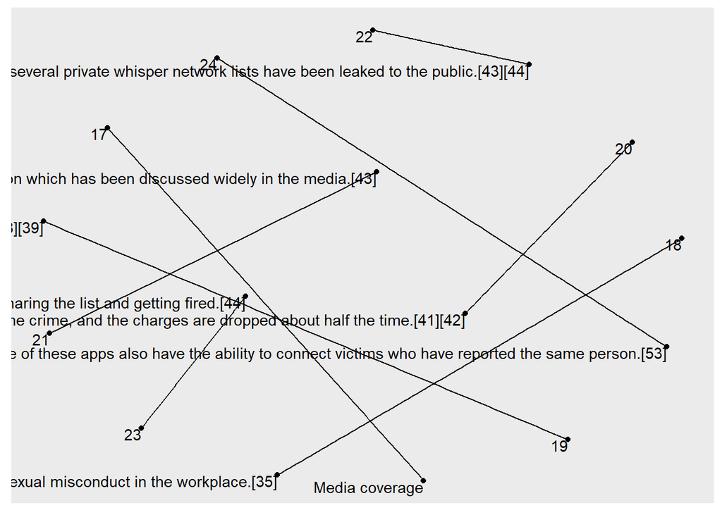

```r
igh = graph.data.frame(edges)
ggraph(igh, layout = "kk") +
  geom_edge_link() +
  geom_node_point() +
  geom_node_text(aes(label = name), vjust = 1, hjust = 1)
```

## Neo4j screenshots of windows service and graph database and queries

[figure not shown]

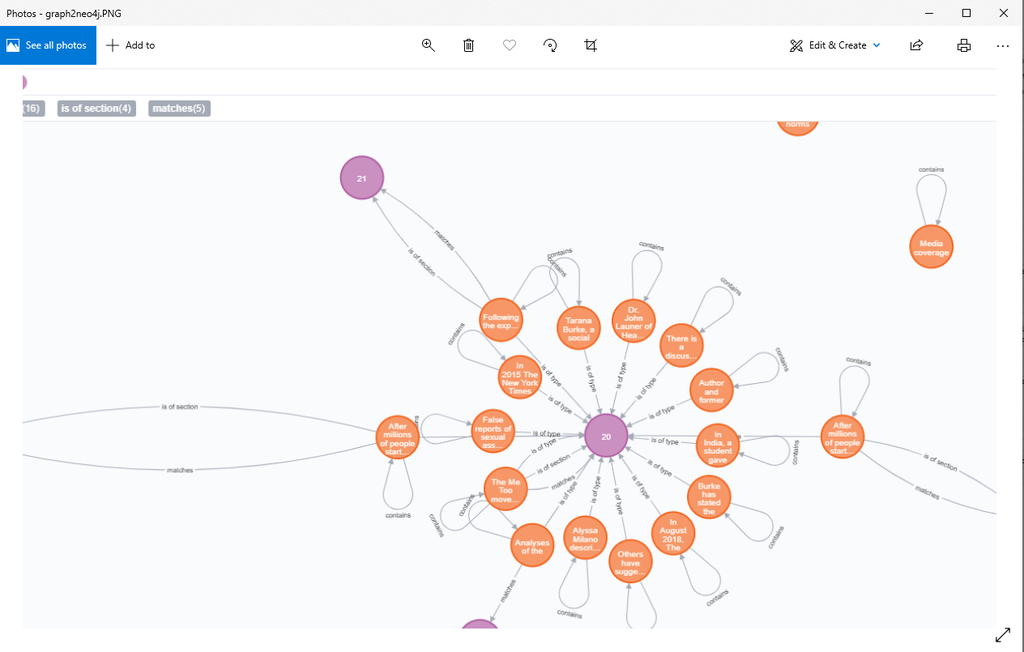

[figure not shown]

## Works cited

These sites were very helpful in understanding how to do this process by connecting R to Neo4j. Not many sites were out there that helped really understand basic understanding and steps except these.

http://rpubs.com/myampol/MY-DATA607-Week12-MySQL-to-Neo4j https://rdrr.io/github/nicolewhite/RNeo4j/ https://neo4j.com/docs/operations-manual/current/